# Data Overview

PISA is the Organisation for Economic Co-operation and Development (OECD)'s Programme for International Student Assessment. PISA measures 15-year-olds’ ability to use their reading, mathematics and science knowledge and skills to meet real-life challenges. For this analysis, I focused on resources, mindsets and math outcomes.

# Gather

```python
#Import libraries/modules
import pandas as pd
import numpy as np
import matplotlib.pyplot as plt
%matplotlib inline
import seaborn as sb
```

```python
#Read data
df = pd.read_csv('pisa2012.csv',sep=',', encoding='latin-1',error_bad_lines=False, index_col=False, dtype='unicode')
```

```python
df.head() #peek @ data
```

|  | Unnamed: 0 | CNT | SUBNATIO | STRATUM | OECD | NC | SCHOOLID | STIDSTD | ST01Q01 | ST02Q01 | ... | W_FSTR75 | W_FSTR76 | W_FSTR77 | W_FSTR78 | W_FSTR79 | W_FSTR80 | WVARSTRR | VAR_UNIT | SENWGT_STU | VER_STU |
| --- | --- | --- | --- | --- | --- | --- | --- | --- | --- | --- | --- | --- | --- | --- | --- | --- | --- | --- | --- | --- | --- |
| 0 | 1 | Albania | 0080000 | ALB0006 | Non-OECD | Albania | 0000001 | 00001 | 10 | 1 | ... | 13.7954 | 13.9235 | 13.1249 | 13.1249 | 4.3389 | 13.0829 | 19 | 1 | 0.2098 | 22NOV13 |
| 1 | 2 | Albania | 0080000 | ALB0006 | Non-OECD | Albania | 0000001 | 00002 | 10 | 1 | ... | 13.7954 | 13.9235 | 13.1249 | 13.1249 | 4.3389 | 13.0829 | 19 | 1 | 0.2098 | 22NOV13 |
| 2 | 3 | Albania | 0080000 | ALB0006 | Non-OECD | Albania | 0000001 | 00003 | 9 | 1 | ... | 12.7307 | 12.7307 | 12.7307 | 12.7307 | 4.2436 | 12.7307 | 19 | 1 | 0.1999 | 22NOV13 |
| 3 | 4 | Albania | 0080000 | ALB0006 | Non-OECD | Albania | 0000001 | 00004 | 9 | 1 | ... | 12.7307 | 12.7307 | 12.7307 | 12.7307 | 4.2436 | 12.7307 | 19 | 1 | 0.1999 | 22NOV13 |
| 4 | 5 | Albania | 0080000 | ALB0006 | Non-OECD | Albania | 0000001 | 00005 | 9 | 1 | ... | 12.7307 | 12.7307 | 12.7307 | 12.7307 | 4.2436 | 12.7307 | 19 | 1 | 0.1999 | 22NOV13 |

5 rows × 636 columns

WOW! 636 columns! Using the PISA dictionary, I am going to narrow that down by coming up with some questions. I am going to focus on mathematics, and study the relationship between resources, societal norms, mindset, and outcomes.

CNT Country code 3-character

STIDSTD Student ID

ST01Q01 International Grade

ST03Q01 Birth - Month

ST03Q02 Birth -Year

ST04Q01 Gender

ST08Q01 Truancy - Late for School

ST09Q01 Truancy - Skip whole school day

ST115Q01 Truancy - Skip classes within school day

ST26Q01 Possessions - desk

ST26Q02 Possessions - own room

ST26Q06 Possessions - Internet

ST27Q01 How many - cellular phones

ST27Q02 How many - televisions

ST27Q03 How many - computers

ST27Q05 How many - rooms bath or shower

ST28Q01 How many books at home

ST35Q02 Subjective Norms -Friends Work Hard on Mathematics

ST35Q04 Subjective Norms - Parents Believe Studying Mathematics Is Important

ST42Q01 Math Anxiety - Worry That It Will Be Difficult

ST46Q01 Math Work Ethic - Homework Completed in Time

ST46Q06 Math Work Ethic - Pay Attention in Classes

ST80Q08 Cognitive Activation - Helps Learn from Mistakes

ST87Q03 Sense of Belonging - Belong at School

ST89Q05 Attitude toward School - Trying Hard is Important

ST91Q01 Perceived Control - Can Succeed with Enough Effort

ST93Q01 Perseverance - Give up easily

PV1MATH Plausible value 1 in mathematics

PV2MATH Plausible value 2 in mathematics

PV3MATH Plausible value 3 in mathematics

PV4MATH Plausible value 4 in mathematics

PV5MATH Plausible value 5 in mathematics

W_FSTUWT FINAL STUDENT WEIGHT

WVARSTRR RANDOMIZED FINAL VARIANCE STRATUM (1-80)

VAR_UNIT RANDOMLY ASSIGNED VARIANCE UNIT

SENWGT_STU Senate weight - sum of weight within the country is 1000

VER_STU Date of the database creation

```python
#redifine dataframe with these columns
df1 = df[['CNT', 'STIDSTD', 'ST01Q01', 'ST03Q01', 'ST03Q02', 'ST04Q01', 'ST08Q01', 'ST09Q01', 'ST115Q01', 'ST26Q01', 'ST26Q02', 'ST26Q06', 'ST27Q01', 'ST27Q02', 'ST27Q03', 'ST27Q05', 'ST28Q01', 'ST35Q02', 'ST35Q04', 'ST42Q01', 'ST46Q01', 'ST46Q06', 'ST80Q08', 'ST87Q03', 'ST89Q05', 'ST91Q01', 'ST93Q01', 'PV1MATH', 'PV2MATH', 'PV3MATH', 'PV4MATH', 'PV5MATH', 'W_FSTUWT', 'WVARSTRR', 'VAR_UNIT', 'SENWGT_STU', 'VER_STU']].copy()
```

```python
df1.shape
```

```
(485490, 37)
```

```python
#save to create a checkpoint that doesn't require reloading the original data
df1.to_csv('PISA_math.csv', index=False)
```

```python
#Read culled data
df1 = pd.read_csv('PISA_math.csv', sep=',', encoding='latin-1',error_bad_lines=False, index_col=False, dtype='unicode')
```

```python
df1.describe()
```

|  | CNT | STIDSTD | ST01Q01 | ST03Q01 | ST03Q02 | ST04Q01 | ST08Q01 | ST09Q01 | ST115Q01 | ST26Q01 | ... | PV1MATH | PV2MATH | PV3MATH | PV4MATH | PV5MATH | W_FSTUWT | WVARSTRR | VAR_UNIT | SENWGT_STU | VER_STU |
| --- | --- | --- | --- | --- | --- | --- | --- | --- | --- | --- | --- | --- | --- | --- | --- | --- | --- | --- | --- | --- | --- |
| count | 485490 | 485490 | 485490 | 485490 | 485490 | 485490 | 479143 | 479131 | 479269 | 473079 | ... | 485490 | 485490 | 485490 | 485490 | 485490 | 485490 | 485490 | 485490 | 485490 | 485490 |
| unique | 68 | 33806 | 8 | 13 | 2 | 2 | 4 | 4 | 4 | 2 | ... | 7063 | 7044 | 7093 | 7091 | 7102 | 39393 | 80 | 3 | 4714 | 1 |
| top | Mexico | 00196 | 10 | 08 | 1996 | Female | None | None | 1 | Yes | ... | 444.158 | 453.5052 | 446.4948 | 464.4103 | 483.1048 | 1 | 21 | 1 | 0.0909 | 22NOV13 |
| freq | 33806 | 68 | 262631 | 42696 | 451476 | 245064 | 306065 | 385998 | 378576 | 419033 | ... | 359 | 348 | 360 | 363 | 360 | 14614 | 6632 | 237874 | 7058 | 485490 |

4 rows × 37 columns

```python
#continue to narrow focus by selecting fewer countries.
df1.CNT.unique()
```

```
array(['Albania', 'United Arab Emirates', 'Argentina', 'Australia',
       'Austria', 'Belgium', 'Bulgaria', 'Brazil', 'Canada',
       'Switzerland', 'Chile', 'Colombia', 'Costa Rica', 'Czech Republic',
       'Germany', 'Denmark', 'Spain', 'Estonia', 'Finland', 'France',
       'United Kingdom', 'Greece', 'Hong Kong-China', 'Croatia',
       'Hungary', 'Indonesia', 'Ireland', 'Iceland', 'Israel', 'Italy',
       'Jordan', 'Japan', 'Kazakhstan', 'Korea', 'Liechtenstein',
       'Lithuania', 'Luxembourg', 'Latvia', 'Macao-China', 'Mexico',
       'Montenegro', 'Malaysia', 'Netherlands', 'Norway', 'New Zealand',
       'Peru', 'Poland', 'Portugal', 'Qatar', 'China-Shanghai',
       'Perm(Russian Federation)', 'Florida (USA)', 'Connecticut (USA)',
       'Massachusetts (USA)', 'Romania', 'Russian Federation',
       'Singapore', 'Serbia', 'Slovak Republic', 'Slovenia', 'Sweden',
       'Chinese Taipei', 'Thailand', 'Tunisia', 'Turkey', 'Uruguay',
       'United States of America', 'Vietnam'], dtype=object)
```

```python
df = (df1.loc[df1['CNT'].isin(['United Arab Emirates', 'Argentina', 'Brazil', 'Canada', 'United Kingdom', 'Korea', 'Florida (USA)', 'Connecticut (USA)', 'Massachusetts (USA)', 'United States of America', 'Vietnam'])])
df.shape
```

```
(91101, 37)
```

# Assess

```python
df.head()
```

|  | CNT | STIDSTD | ST01Q01 | ST03Q01 | ST03Q02 | ST04Q01 | ST08Q01 | ST09Q01 | ST115Q01 | ST26Q01 | ... | PV1MATH | PV2MATH | PV3MATH | PV4MATH | PV5MATH | W_FSTUWT | WVARSTRR | VAR_UNIT | SENWGT_STU | VER_STU |
| --- | --- | --- | --- | --- | --- | --- | --- | --- | --- | --- | --- | --- | --- | --- | --- | --- | --- | --- | --- | --- | --- |
| 4743 | United Arab Emirates | 00001 | 10 | 08 | 1996 | Male | One or two times | One or two times | 1 | Yes | ... | 328.2521 | 386.6724 | 341.494 | 336.0414 | 316.568 | 2.8838 | 77 | 1 | 0.071 | 22NOV13 |
| 4744 | United Arab Emirates | 00002 | 10 | 06 | 1996 | Male | None | One or two times | 1 | Yes | ... | 270.7665 | 193.6517 | 267.6507 | 255.1877 | 246.6194 | 2.8838 | 77 | 1 | 0.071 | 22NOV13 |
| 4745 | United Arab Emirates | 00003 | 10 | 09 | 1996 | Male | None | None | 1 | Yes | ... | 314.9322 | 297.7956 | 259.6277 | 272.0907 | 323.5005 | 2.8838 | 77 | 1 | 0.071 | 22NOV13 |
| 4746 | United Arab Emirates | 00004 | 9 | 12 | 1996 | Male | None | None | 1 | NaN | ... | 250.2804 | 233.1438 | 223.7965 | 254.954 | 295.4588 | 2.8838 | 77 | 1 | 0.071 | 22NOV13 |
| 4747 | United Arab Emirates | 00005 | 10 | 03 | 1996 | Male | None | None | 1 | Yes | ... | 310.1807 | 313.2965 | 313.2965 | 279.8021 | 299.2756 | 2.8838 | 77 | 1 | 0.071 | 22NOV13 |

5 rows × 37 columns

```python
df.info()
```

```
<class 'pandas.core.frame.DataFrame'>
Int64Index: 91101 entries, 4743 to 485489
Data columns (total 37 columns):
 #   Column      Non-Null Count  Dtype
---  ------      --------------  -----
 0   CNT         91101 non-null  object
 1   STIDSTD     91101 non-null  object
 2   ST01Q01     91101 non-null  object
 3   ST03Q01     91101 non-null  object
 4   ST03Q02     91101 non-null  object
 5   ST04Q01     91101 non-null  object
 6   ST08Q01     89899 non-null  object
 7   ST09Q01     89908 non-null  object
 8   ST115Q01    89950 non-null  object
 9   ST26Q01     87826 non-null  object
```

[output cut: 29 more lines]

```python
pd.set_option('display.max_columns', None) #see all columns
df.describe()
```

|  | CNT | STIDSTD | ST01Q01 | ST03Q01 | ST03Q02 | ST04Q01 | ST08Q01 | ST09Q01 | ST115Q01 | ST26Q01 | ST26Q02 | ST26Q06 | ST27Q01 | ST27Q02 | ST27Q03 | ST27Q05 | ST28Q01 | ST35Q02 | ST35Q04 | ST42Q01 | ST46Q01 | ST46Q06 | ST80Q08 | ST87Q03 | ST89Q05 | ST91Q01 | ST93Q01 | PV1MATH | PV2MATH | … |
| --- | --- | --- | --- | --- | --- | --- | --- | --- | --- | --- | --- | --- | --- | --- | --- | --- | --- | --- | --- | --- | --- | --- | --- | --- | --- | --- | --- | --- | --- | --- |
| count | 91101 | 91101 | 91101 | 91101 | 91101 | 91101 | 89899 | 89908 | 89950 | 87826 | 88732 | 88349 | 89418 | 89287 | 88540 | 88849 | 89107 | 59178 | 59182 | 58785 | 58803 | 58603 | 58520 | 58045 | 58103 | 58232 | 58559 | 91101 | 91101 | … |
| unique | 11 | 21544 | 8 | 13 | 2 | 2 | 4 | 4 | 4 | 2 | 2 | 2 | 4 | 4 | 4 | 4 | 6 | 4 | 4 | 4 | 4 | 4 | 4 | 4 | 4 | 4 | 5 | 5489 | 5467 | … |
| top | Canada | 00947 | 10 | 09 | 1996 | Female | None | None | 1 | Yes | Yes | Yes | Three or more | Three or more | Three or more | One | 26-100 books | Agree | Strongly agree | Agree | Agree | Agree | Always or almost always | Agree | Strongly agree | Strongly agree | Not much like me | 473.7576 | 470.6418 | … |
| freq | 21544 | 11 | 52500 | 8020 | 76159 | 46463 | 59450 | 68521 | 73268 | 70623 | 71224 | 75930 | 71759 | 45982 | 30416 | 34705 | 24424 | 29581 | 27741 | 24776 | 27654 | 32729 | 21227 | 31664 | 32497 | 34926 | 21466 | 77 | 80 | … |

```python
#student id is only unique within the student's country
df[(df['STIDSTD'] == '01291')]
```

|  | CNT | STIDSTD | ST01Q01 | ST03Q01 | ST03Q02 | ST04Q01 | ST08Q01 | ST09Q01 | ST115Q01 | ST26Q01 | ST26Q02 | ST26Q06 | ST27Q01 | ST27Q02 | ST27Q03 | ST27Q05 | ST28Q01 | ST35Q02 | ST35Q04 | ST42Q01 | ST46Q01 | ST46Q06 | ST80Q08 | ST87Q03 | ST89Q05 | ST91Q01 | ST93Q01 | PV1MATH | PV2MATH | … |
| --- | --- | --- | --- | --- | --- | --- | --- | --- | --- | --- | --- | --- | --- | --- | --- | --- | --- | --- | --- | --- | --- | --- | --- | --- | --- | --- | --- | --- | --- | --- |
| 6033 | United Arab Emirates | 01291 | 11 | 04 | 1996 | Male | None | None | 1 | Yes | Yes | Yes | Three or more | Three or more | Three or more | Three or more | 101-200 books | Disagree | Strongly agree | Agree | Agree | Agree | Often | Agree | Agree | Agree | Not at all like me | 339.7803 | 362.3695 | … |
| 17533 | Argentina | 01291 | 10 | 11 | 1996 | Female | None | None | 1 | Yes | Yes | Yes | Two | Two | Two | None | 201-500 books | NaN | NaN | Disagree | NaN | NaN | Always or almost always | Agree | Agree | Strongly agree | NaN | 495.7236 | 491.05 | … |
| 56556 | Brazil | 01291 | 11 | 06 | 1996 | Male | None | None | 2 | Yes | Yes | Yes | Three or more | Three or more | Two | Three or more | 26-100 books | Disagree | Agree | NaN | Agree | Agree | NaN | NaN | NaN | NaN | Not at all like me | 418.9204 | 473.446 | … |
| 75760 | Canada | 01291 | 10 | 05 | 1996 | Female | None | One or two times | 2 | Yes | Yes | Yes | Three or more | Three or more | Three or more | NaN | 11-25 books | Agree | Agree | NaN | Agree | Agree | NaN | NaN | NaN | NaN | Not much like me | 440.3412 | 361.6685 | … |
| 190407 | United Kingdom | 01291 | 12 | 05 | 1997 | Female | None | None | 1 | Yes | Yes | Yes | Three or more | Three or more | Three or more | One | 26-100 books | Disagree | Agree | NaN | Agree | Agree | NaN | NaN | NaN | NaN | Not much like me | 462.7746 | 515.7423 | … |
| 292150 | Korea | 01291 | 10 | 05 | 1996 | Male | None | None | 1 | Yes | Yes | Yes | Three or more | One | Two | Two | 201-500 books | Agree | Agree | NaN | Strongly agree | Agree | NaN | NaN | NaN | NaN | Not much like me | 740.31 | 694.3527 | … |
| 408445 | Florida (USA) | 01291 | 10 | 12 | 1996 | Female | One or two times | None | 1 | Yes | Yes | Yes | Three or more | Three or more | Three or more | Two | 26-100 books | Agree | Agree | Disagree | Strongly agree | Strongly agree | Sometimes | Agree | Strongly agree | Strongly agree | Not at all like me | 455.842 | 538.4094 | … |
| 410341 | Connecticut (USA) | 01291 | 10 | 03 | 1997 | Male | None | None | 1 | Yes | Yes | Yes | Three or more | Three or more | Three or more | Three or more | More than 500 books | NaN | NaN | Strongly disagree | NaN | NaN | NaN | Agree | Strongly agree | Strongly agree | NaN | 699.0263 | 688.9001 | … |
| 412038 | Massachusetts (USA) | 01291 | 10 | 05 | 1997 | Female | None | None | 1 | Yes | Yes | Yes | Three or more | Two | Two | One | 101-200 books | Agree | Strongly agree | Disagree | Strongly agree | Agree | Always or almost always | Agree | Agree | Agree | Not much like me | 536.0726 | 522.8307 | … |
| 476843 | United States of America | 01291 | 10 | 06 | 1997 | Male | None | None | 1 | Yes | Yes | Yes | Three or more | One | Three or more | One | 201-500 books | Disagree | Strongly agree | Agree | Agree | Agree | Sometimes | Agree | Agree | Strongly agree | Not much like me | 435.356 | 454.0505 | … |
| 481821 | Vietnam | 01291 | 10 | 09 | 1996 | Male | None | None | 1 | Yes | Yes | No | Two | One | None | None | 0-10 books | NaN | NaN | Agree | NaN | NaN | Often | Strongly agree | Agree | Strongly agree | NaN | 549.7819 | 547.4451 | … |

```python
print(df['ST03Q02'].unique())
print(df['ST08Q01'].unique())
print(df['ST09Q01'].unique())
print(df['ST115Q01'].unique())
print(df['ST87Q03'].unique())
print(df['ST93Q01'].unique())
print(df['ST26Q02'].unique())
print(df['W_FSTUWT'].unique())
```

```
['1996' '1997']
['One or two times  ' 'None  ' 'Three or four times  ' nan
 'Five or more times  ']
['One or two times  ' 'None  ' nan 'Five or more times  '
 'Three or four times  ']
['1' '4' '2' nan '3']
['Strongly agree' nan 'Agree' 'Disagree' 'Strongly disagree']
['Very much like me' nan 'Somewhat like me' 'Not at all like me'
 'Mostly like me' 'Not much like me']
['No' 'Yes' nan]
['2.8838' '4.4539' '4.5743' ... '195.5566' '65.7647' '62.4825']
```

```python
df.isna().sum()
```

```
CNT               0
STIDSTD           0
ST01Q01           0
ST03Q01           0
ST03Q02           0
ST04Q01           0
ST08Q01        1202
ST09Q01        1193
ST115Q01       1151
ST26Q01        3275
ST26Q02        2369
ST26Q06        2752
ST27Q01        1683
ST27Q02        1814
ST27Q03        2561
ST27Q05        2252
ST28Q01        1994
ST35Q02       31923
ST35Q04       31919
ST42Q01       32316
ST46Q01       32298
ST46Q06       32498
ST80Q08       32581
ST87Q03       33056
ST89Q05       32998
ST91Q01       32869
ST93Q01       32542
PV1MATH           0
PV2MATH           0
PV3MATH           0
PV4MATH           0
PV5MATH           0
W_FSTUWT          0
WVARSTRR          0
VAR_UNIT          0
SENWGT_STU        0
VER_STU           0
dtype: int64
```

```python
#The plausible values aren't stored as numbers/floats
df.PV1MATH.describe()
```

```
count        91101
unique        5489
top       473.7576
freq            77
Name: PV1MATH, dtype: object
```

## Quality

- Plausible values dtype is object; should be float
- ST115Q01, skipped classes within day, dtype is object; should be int
- ST08Q01, tardies; ST09Q01, absences; ST26Q01, desk ownership; ST26Q02, room ownership; ST26Q06, internet access; ST27Q01, cell phones; ST27Q02, TVs; ST27Q03, PCs; ST27Q05, bathrooms; ST28Q01, books; ST35Q02, friends' work ethic in math; ST35Q04, parents belief in math importance; ST42Q01, worry about math difficulty; ST46Q01, math homework timely; ST46Q06, pay attention in math; ST80Q08, learn from mistakes; ST87Q03, feeling of belonging at school; ST89Q05, best effort is important; ST91Q01, effort results in success; ST93Q01, gives up easily, dtype is object; should be categorical
- Lots of null/NaN values in the categorical response columns

## Tidiness

- Some United States values broken out into States
- Student IDs are not entirely unique
- ST01Q01: International Grade, ST03Q01: Birth - Month, ST03Q02: Birth -Year, W_FSTUWT: FINAL STUDENT WEIGHT, WVARSTRR: RANDOMIZED FINAL VARIANCE STRATUM (1-80), VAR_UNIT: RANDOMLY ASSIGNED VARIANCE UNIT, SENWGT_STU: Senate weight - sum of weight within the country is 1000, and VER_STU: Date of the database creation, do not appear to valuable to my avenue of exploration.

# Clean

```python
#create copies of the dataframes to work with
df_clean = df.copy()
```

#### Plausible values, and ST115Q01, skipped classes within day, dtype is object; should be float

#### ST08Q01, tardies; ST09Q01, absences; ST26Q01, desk ownership; ST26Q02, room ownership; ST26Q06, internet access; ST27Q01, cell phones; ST27Q02, TVs; ST27Q03, PCs; ST27Q05, bathrooms; ST28Q01, books; ST35Q02, friends' work ethic in math; ST35Q04, parents belief in math importance; ST42Q01, worry about math difficulty; ST46Q01, math homework timely; ST46Q06, pay attention in math; ST80Q08, learn from mistakes; ST87Q03, feeling of belonging at school; ST89Q05, best effort is important; ST91Q01, effort results in success; ST93Q01, gives up easily, dtype is object; should be categorical

##### Define

Convert datatypes with `.astype(float)`, and `pd.api.types.CategoricalDtype`

##### Code

```python
df_clean[['ST115Q01', 'PV1MATH', 'PV2MATH', 'PV3MATH', 'PV4MATH', 'PV5MATH']] = df_clean[['ST115Q01', 'PV1MATH', 'PV2MATH', 'PV3MATH', 'PV4MATH', 'PV5MATH']].astype(float)
```

```python
def catconv1(A,B):#A=define type, B=column to change
    cat_type1 = ['None  ', 'One or two times  ', 'Three or four times  ', 'Five or more times  ']
    A =  pd.api.types.CategoricalDtype(ordered=True, categories=cat_type1)
    df_clean[B] = df_clean[B].astype(A)

catconv1("tardies", "ST08Q01")
catconv1("absences", "ST09Q01")

def catconv2(A,B):#A=define type, B=column to change
    cat_type2 = ['None', 'One', 'Two', 'Three or more']
    A =  pd.api.types.CategoricalDtype(ordered=True, categories=cat_type2)
    df_clean[B] = df_clean[B].astype(A)

catconv2("cells", "ST27Q01")
catconv2("tvs", "ST27Q02")
catconv2("PCs", "ST27Q03")
catconv2("baths", "ST27Q05")

def catconv3(A,B):#A=define type, B=column to change
    cat_type3 = ['Strongly agree', 'Agree', 'Disagree', 'Strongly disagree']
    A =  pd.api.types.CategoricalDtype(ordered=True, categories=cat_type3)
    df_clean[B] = df_clean[B].astype(A)

catconv3("friends", "ST35Q02")
catconv3("parents", "ST35Q04")
catconv3("math_worries", "ST42Q01")
catconv3("mathHW", "ST46Q01")
catconv3("math_attns", "ST46Q06")
catconv3("belonging", "ST87Q03")
catconv3("best_efforts", "ST89Q05")
catconv3("success", "ST91Q01")

cat_type4 = ['0-10 books ', '11-25 books ', '26-100 books ', '101-200 books ', '201-500 books ', 'More than 500 books']
book_num =  pd.api.types.CategoricalDtype(ordered=True, categories=cat_type4)
df_clean["ST28Q01"] = df_clean["ST28Q01"].astype(book_num)

cat_type5 = ['Never or rarely', 'Sometimes', 'Often', 'Always or almost always']
learn =  pd.api.types.CategoricalDtype(ordered=True, categories=cat_type5)
df_clean["ST80Q08"] = df_clean["ST80Q08"].astype(learn)

cat_type6 = ['Not at all like me','Not much like me', 'Somewhat like me', 'Mostly like me', 'Very much like me']
giveup =  pd.api.types.CategoricalDtype(ordered=True, categories=cat_type6)
df_clean["ST93Q01"] = df_clean["ST93Q01"].astype(giveup)
```

##### Test

```python
df_clean.info()
```

```
<class 'pandas.core.frame.DataFrame'>
Int64Index: 91101 entries, 4743 to 485489
Data columns (total 37 columns):
 #   Column      Non-Null Count  Dtype
---  ------      --------------  -----
 0   CNT         91101 non-null  object
 1   STIDSTD     91101 non-null  object
 2   ST01Q01     91101 non-null  object
 3   ST03Q01     91101 non-null  object
 4   ST03Q02     91101 non-null  object
 5   ST04Q01     91101 non-null  object
 6   ST08Q01     89899 non-null  category
 7   ST09Q01     89908 non-null  category
 8   ST115Q01    89950 non-null  float64
 9   ST26Q01     87826 non-null  object
```

[output cut: 29 more lines]

```python
df_clean.PV1MATH.describe()
```

```
count    91101.000000
mean       462.501296
std        102.929866
min         19.792800
25%        386.984000
50%        459.658800
75%        534.670500
max        891.346000
Name: PV1MATH, dtype: float64
```

#### Lots of null/NaN values in the categorical response columns

##### Define

Select rows with values in all response columns using `.dropna()`

##### Code

```python
df_clean = df_clean.dropna(subset=['ST08Q01', 'ST09Q01', 'ST115Q01', 'ST26Q01', 'ST26Q02', 'ST26Q06', 'ST27Q01', 'ST27Q02', 'ST27Q03', 'ST27Q05', 'ST28Q01', 'ST35Q02', 'ST35Q04', 'ST42Q01', 'ST46Q01', 'ST46Q06', 'ST80Q08', 'ST87Q03', 'ST89Q05', 'ST91Q01', 'ST93Q01'])
```

##### Test

```python
df_clean.isna().sum()
```

```
CNT           0
STIDSTD       0
ST01Q01       0
ST03Q01       0
ST03Q02       0
ST04Q01       0
ST08Q01       0
ST09Q01       0
ST115Q01      0
ST26Q01       0
ST26Q02       0
ST26Q06       0
ST27Q01       0
ST27Q02       0
ST27Q03       0
ST27Q05       0
ST28Q01       0
ST35Q02       0
ST35Q04       0
ST42Q01       0
ST46Q01       0
ST46Q06       0
ST80Q08       0
ST87Q03       0
ST89Q05       0
ST91Q01       0
ST93Q01       0
PV1MATH       0
PV2MATH       0
PV3MATH       0
PV4MATH       0
PV5MATH       0
W_FSTUWT      0
WVARSTRR      0
VAR_UNIT      0
SENWGT_STU    0
VER_STU       0
dtype: int64
```

#### Some United States values broken out into States

##### Define

rename those rows to "United States of America" with `.replace()`

##### Code

```python
df_clean.replace(['Massachusetts (USA)', 'Florida (USA)', 'Connecticut (USA)'], 'United States of America', inplace=True)
```

##### Test

```python
df_clean['CNT'].value_counts()
```

```
Canada                      6242
Brazil                      4928
United Kingdom              3798
United Arab Emirates        3272
United States of America    3018
Korea                       1631
Vietnam                     1496
Argentina                   1448
Name: CNT, dtype: int64
```

##### Student IDs are not entirely unique

##### ST01Q01: International Grade, ST03Q01: Birth - Month, ST03Q02: Birth -Year, W_FSTUWT: FINAL STUDENT WEIGHT, WVARSTRR: RANDOMIZED FINAL VARIANCE STRATUM (1-80), VAR_UNIT: RANDOMLY ASSIGNED VARIANCE UNIT, SENWGT_STU: Senate weight - sum of weight within the country is 1000, and VER_STU: Date of the database creation, do not appear to valuable to my avenue of exploration.

##### Define

Eliminate these columns using `.drop()`. Give remaining columns more meaningful names with `.rename()`.

##### Code

```python
df_clean.drop(['STIDSTD', 'ST01Q01', 'ST03Q01', 'ST03Q02', 'W_FSTUWT', 'WVARSTRR', 'VAR_UNIT', 'SENWGT_STU', 'VER_STU'], axis=1, inplace=True)
df_clean.rename(columns={'ST04Q01':'SEX', 'ST08Q01':'TARDY', 'ST09Q01':'ABSENT', 'ST115Q01':'SKIPPED', 'ST26Q01':'DESK', 'ST26Q02':'OWN_ROOM', 'ST26Q06':'INTERNET', 'ST27Q01':'CELLULAR', 'ST27Q02':'TV', 'ST27Q03':'PC', 'ST27Q05':'BATHROOM', 'ST28Q01':'BOOKS', 'ST35Q02':'MATH_FRIENDS_WORK_HARD', 'ST35Q04':'PARENTS_MATH_IMPORTANT', 'ST42Q01':'WORRY_MATH_DIFF', 'ST46Q01':'MATHHW_ONTIME', 'ST46Q06':'MATH_PAY_ATTN', 'ST80Q08':'LEARN_FROM_MISTAKES', 'ST87Q03':'SCHOOL_BELONGING', 'ST89Q05':'BEST_EFFORT_IMPORTANT', 'ST91Q01':'EFFORT=SUCCESS', 'ST93Q01':'GIVE_UP_EASILY'}, inplace=True)
```

##### Test

```python
df_clean.info()
```

```
<class 'pandas.core.frame.DataFrame'>
Int64Index: 25833 entries, 4743 to 485487
Data columns (total 28 columns):
 #   Column                  Non-Null Count  Dtype
---  ------                  --------------  -----
 0   CNT                     25833 non-null  object
 1   SEX                     25833 non-null  object
 2   TARDY                   25833 non-null  category
 3   ABSENT                  25833 non-null  category
 4   SKIPPED                 25833 non-null  float64
 5   DESK                    25833 non-null  object
 6   OWN_ROOM                25833 non-null  object
 7   INTERNET                25833 non-null  object
 8   CELLULAR                25833 non-null  category
 9   TV                      25833 non-null  category
```

[output cut: 20 more lines]

```python
df_clean.to_csv('PISA_math_clean.csv', index=False)
```

# Analyze

*NOTE FROM PISA TECHNICAL GUIDE*

It cannot be emphasised too strongly that the plausible values are not a substitute for test scores for individuals. Plausible values incorporate responses to test items and information about the background of responses; therefore, they cannot be used to compare individuals.

https://www.oecd.org/pisa/sitedocument/PISA-2015-Technical-Report-Chapter-9-Scaling-PISA-Data.pdf

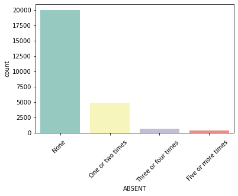

```python
def uniplot(A):
    sb.countplot(x=A, data=df_clean, palette="Set3")

uniplot("ABSENT")
plt.xticks(rotation=45);
```

Most assessed students had great attendance.

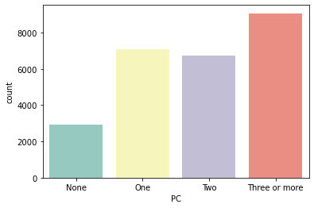

```python
uniplot("PC")
```

Multiple PCs are a trend.

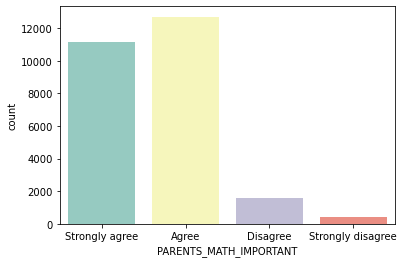

```python
uniplot("PARENTS_MATH_IMPORTANT")
```

Most students perceive their parents as finding math important.

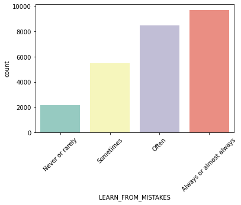

```python
uniplot("LEARN_FROM_MISTAKES")
plt.xticks(rotation=45);
```

A lot of students identify as sometimes, rarely or never learning from their mistakes, but most said often, almost always or always.

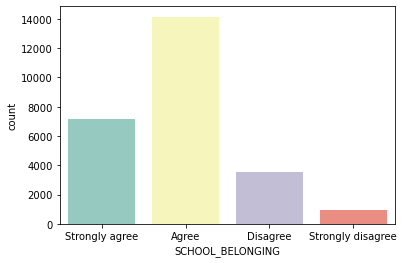

```python
uniplot("SCHOOL_BELONGING")
```

Most assessed students have a sense of belonging at school.

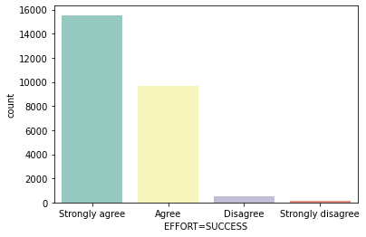

```python
uniplot("EFFORT=SUCCESS")
```

Most students agree that success is attainable with enough effort.

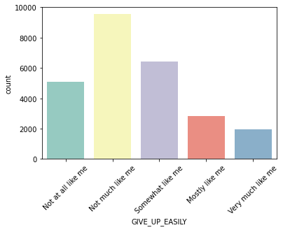

```python
uniplot("GIVE_UP_EASILY")
plt.xticks(rotation=45);
```

```python
#create new column of the mean plausible value, MEAN_PVMATH
df_clean['MEAN_PVMATH'] = (df_clean['PV1MATH'] + df_clean['PV2MATH'] + df_clean['PV3MATH'] + df_clean['PV4MATH'] + df_clean['PV5MATH'])/5
df_clean.drop(['PV1MATH', 'PV2MATH', 'PV3MATH', 'PV4MATH', 'PV5MATH'], axis=1, inplace=True)
df_clean.head()
```

|  | CNT | SEX | TARDY | ABSENT | SKIPPED | DESK | OWN_ROOM | INTERNET | CELLULAR | TV | PC | BATHROOM | BOOKS | MATH_FRIENDS_WORK_HARD | PARENTS_MATH_IMPORTANT | WORRY_MATH_DIFF | MATHHW_ONTIME | MATH_PAY_ATTN | LEARN_FROM_MISTAKES | SCHOOL_BELONGING | BEST_EFFORT_IMPORTANT | EFFORT=SUCCESS | GIVE_UP_EASILY | MEAN_PVMATH |
| --- | --- | --- | --- | --- | --- | --- | --- | --- | --- | --- | --- | --- | --- | --- | --- | --- | --- | --- | --- | --- | --- | --- | --- | --- |
| 4743 | United Arab Emirates | Male | One or two times | One or two times | 1.0 | Yes | No | Yes | Three or more | Two | One | Two | 101-200 books | Agree | Strongly disagree | Strongly agree | Strongly agree | Agree | Never or rarely | Strongly agree | Strongly disagree | Strongly agree | Very much like me | 341.80558 |
| 4747 | United Arab Emirates | Male | None | None | 1.0 | Yes | Yes | Yes | None | One | One | One | 0-10 books | Agree | Agree | Agree | Strongly agree | Strongly agree | Always or almost always | Agree | Agree | Strongly agree | Very much like me | 303.17028 |
| 4751 | United Arab Emirates | Male | One or two times | None | 2.0 | Yes | Yes | Yes | Three or more | Three or more | Three or more | Three or more | 0-10 books | Strongly agree | Strongly agree | Strongly agree | Strongly agree | Disagree | Sometimes | Strongly agree | Strongly agree | Strongly agree | Very much like me | 304.65024 |
| 4758 | United Arab Emirates | Male | None | None | 1.0 | Yes | Yes | Yes | One | Two | Three or more | Three or more | 0-10 books | Agree | Disagree | Strongly agree | Strongly agree | Disagree | Always or almost always | Agree | Strongly agree | Agree | Mostly like me | 251.76040 |
| 4764 | United Arab Emirates | Male | None | None | 3.0 | Yes | Yes | Yes | Three or more | Two | Three or more | Two | 0-10 books | Disagree | Strongly agree | Agree | Strongly agree | Strongly agree | Often | Strongly agree | Agree | Agree | Very much like me | 389.94392 |

#### Are the plausible values for our selected countries normally distributed?

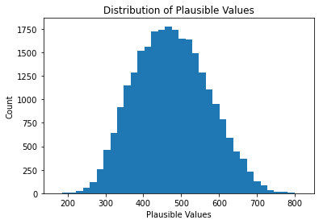

```python
n_bins=np.arange(df_clean["MEAN_PVMATH"].min()-10, df_clean["MEAN_PVMATH"].max()+10, 18)
plt.hist(data=df_clean, x="MEAN_PVMATH", bins=n_bins)
plt.title('Distribution of Plausible Values')
plt.xlabel('Plausible Values')
plt.ylabel('Count');
```

The distribution of plausible values from our subset is normal.

#### How do the country's plausible values, as a mean, compare to one another?

```python
#groupby to see data by country
df_CNT = df_clean.groupby(['CNT']).mean()
df_CNT.sort_values(by='MEAN_PVMATH', inplace=True)
df_CNT = df_CNT.reset_index()
df_CNT
```

|  | CNT | SKIPPED | MEAN_PVMATH |
| --- | --- | --- | --- |
| 0 | Brazil | 1.222403 | 395.636104 |
| 1 | Argentina | 1.522790 | 407.605141 |
| 2 | United Arab Emirates | 1.300733 | 439.248805 |
| 3 | United States of America | 1.162028 | 493.433613 |
| 4 | United Kingdom | 1.164560 | 498.601354 |
| 5 | Vietnam | 1.068850 | 514.321235 |
| 6 | Canada | 1.283883 | 515.942028 |
| 7 | Korea | 1.042305 | 557.647878 |

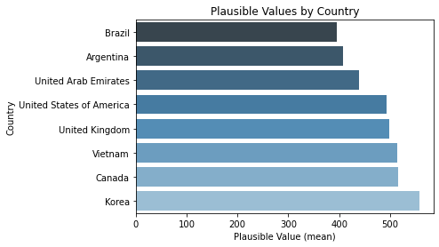

```python
labels = ['Brazil', 'Argentina', 'United Arab Emirates', 'United States of America', 'United Kingdom', 'Vietnam', 'Canada', 'Korea']
g=sb.barplot(x="MEAN_PVMATH", y="CNT", data=df_CNT,
                 palette="Blues_d")
g.set_yticklabels(labels)
plt.title('Plausible Values by Country')
plt.xlabel('Plausible Value (mean)')
plt.ylabel('Country');
```

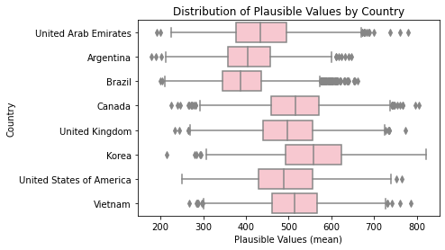

```python
def bibox(A):
    return sb.boxplot(data=df_clean, x='MEAN_PVMATH', y=A, color = "pink");

bibox('CNT')
plt.title('Distribution of Plausible Values by Country')
plt.xlabel('Plausible Values (mean)')
plt.ylabel('Country');
```

```python
df_clean.mean()  #mean for whole dataframe
```

```
SKIPPED          1.228196
MEAN_PVMATH    474.565789
dtype: float64
```

```python
df_clean.groupby("CNT").mean() #mean by country
```

| CNT | SKIPPED | MEAN_PVMATH |
| --- | --- | --- |
| Argentina | 1.522790 | 407.605141 |
| Brazil | 1.222403 | 395.636104 |
| Canada | 1.283883 | 515.942028 |
| Korea | 1.042305 | 557.647878 |
| United Arab Emirates | 1.300733 | 439.248805 |
| United Kingdom | 1.164560 | 498.601354 |
| United States of America | 1.162028 | 493.433613 |
| Vietnam | 1.068850 | 514.321235 |

#### Which measured factors appear to have the most significant impact on plausible values?

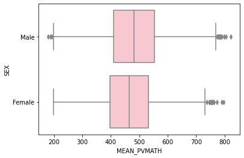

```python
bibox('SEX')
```

Males fared slightly better.

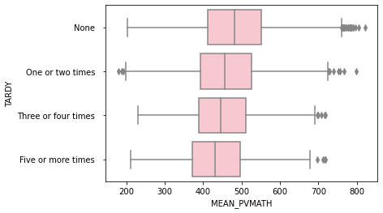

```python
bibox('TARDY')
```

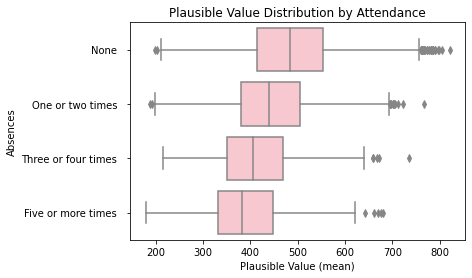

```python
bibox('ABSENT')
plt.title('Plausible Value Distribution by Attendance')
plt.xlabel('Plausible Value (mean)')
plt.ylabel('Absences');
```

Tardies negativevly impact PV, but absences appear to have a more meaningful impact on PV.

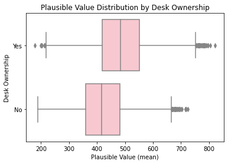

```python
bibox('DESK')
plt.title('Plausible Value Distribution by Desk Ownership')
plt.xlabel('Plausible Value (mean)')
plt.ylabel('Desk Ownership');
```

Desk ownership appears to have a significant impact on PV.

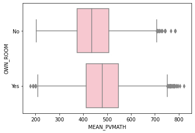

```python
bibox('OWN_ROOM')
```

Students with their own rooms tend to do better.

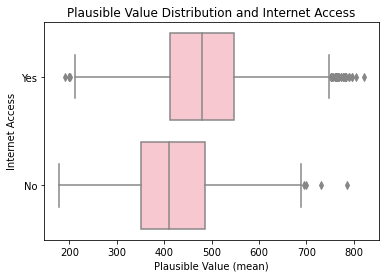

```python
bibox('INTERNET')
plt.title('Plausible Value Distribution and Internet Access')
plt.xlabel('Plausible Value (mean)')
plt.ylabel('Internet Access');
```

Internet access appears to have a significant impact on PV.

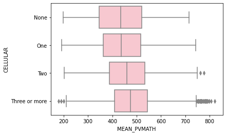

```python
bibox('CELLULAR')
```

Cell phones have a small positive impact, but there are many more outliers in the 3 or more group, in both directions.

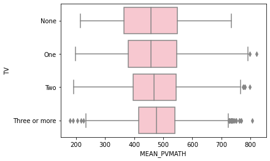

```python
bibox('TV')
```

A similar effect as cell phones is observed with TVs.

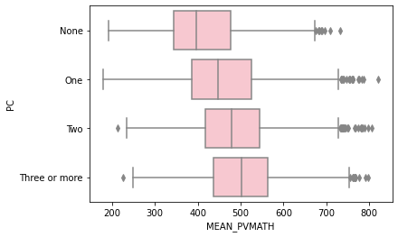

```python
bibox('PC')
```

While there are some higher PVs outlying for fewer PCs, more does have a positive impact, with a higher minimum bound.

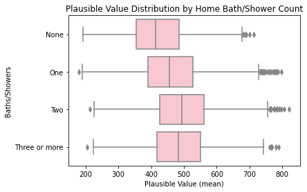

```python
bibox('BATHROOM')
plt.title('Plausible Value Distribution by Home Bath/Shower Count')
plt.xlabel('Plausible Value (mean)')
plt.ylabel('Baths/Showers');
```

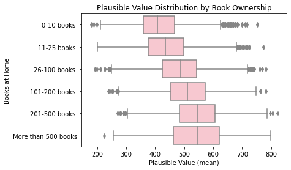

```python
bibox("BOOKS")
plt.title('Plausible Value Distribution by Book Ownership')
plt.xlabel('Plausible Value (mean)')
plt.ylabel('Books at Home');
```

Books appear to have a meaningful impact on PV, although more than 500 isn't significantly better than 201-500.

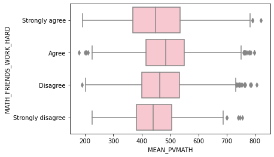

```python
bibox("MATH_FRIENDS_WORK_HARD")
```

Math peer pressure does not seem particularly relevant; those students strongly disagreeing that their friends work hard at math do not appear to fare that much worse than those that strongly agree.

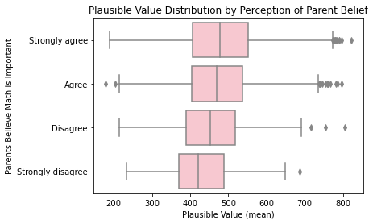

```python
bibox('PARENTS_MATH_IMPORTANT')
plt.title('Plausible Value Distribution by Perception of Parent Belief')
plt.xlabel('Plausible Value (mean)')
plt.ylabel('Parents Believe Math is Important');
```

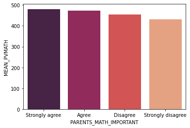

```python
df_PMI = df_clean.groupby(['PARENTS_MATH_IMPORTANT']).mean()
df_PMI = df_PMI.reset_index()
g=sb.barplot(x="PARENTS_MATH_IMPORTANT", y="MEAN_PVMATH", palette="rocket", data=df_PMI)
```

Perception of parent belief in the importance of math appears relevant.

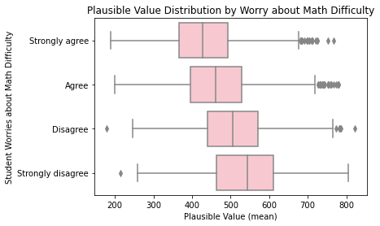

```python
bibox('WORRY_MATH_DIFF')
plt.title('Plausible Value Distribution by Worry about Math Difficulty')
plt.xlabel('Plausible Value (mean)')
plt.ylabel('Student Worries about Math Difficulty');
```

Math anxiety appears relevant to PV.

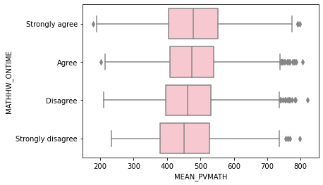

```python
bibox('MATHHW_ONTIME')
```

There is slight positive movement with the distribution of PV for students reporting that homework is turned in on time.

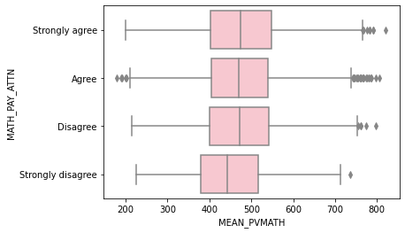

```python
bibox('MATH_PAY_ATTN')
```

Paying attention in math class appears almost irrelevant, except for those that reported that they strongly disagree.

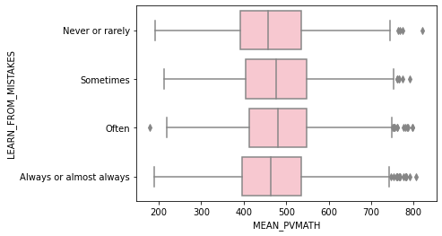

```python
bibox('LEARN_FROM_MISTAKES')
```

Students that report always or almost always learning from mistakes are almost the same as students that reported they never or rarely learned from mistakes.

```python
bibox('SCHOOL_BELONGING')
```

[output not shown]

[output not shown]

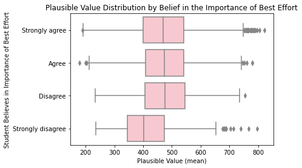

```python
bibox('BEST_EFFORT_IMPORTANT')
plt.title('Plausible Value Distribution by Belief in the Importance of Best Effort')
plt.xlabel('Plausible Value (mean)')
plt.ylabel('Student Believes in Importance of Best Effort');
```

Best effort being important appears to be a belief relevant to PV.

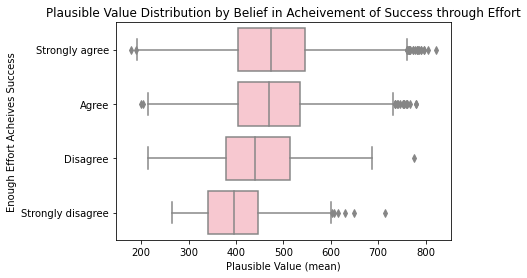

```python
bibox('EFFORT=SUCCESS')
plt.title('Plausible Value Distribution by Belief in Acheivement of Success through Effort')
plt.xlabel('Plausible Value (mean)')
plt.ylabel('Enough Effort Acheives Success');
```

Effort being significant to success being important appears to be a belief relevant to PV.

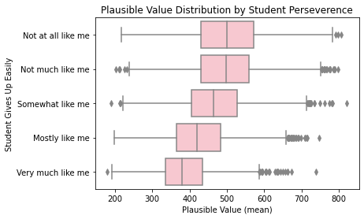

```python
bibox('GIVE_UP_EASILY')
plt.title('Plausible Value Distribution by Student Perseverence')
plt.xlabel('Plausible Value (mean)')
plt.ylabel('Student Gives Up Easily');
```

Perseverence appears to have significant impact on PV.